# Data Cleaning

## Introduction

### Libraries

```r
# load these packages
pacman::p_load(data.table, rmarkdown, dplyr, Hmisc, lubridate, caret, tm, zoo,
    stringr, syuzhet, ggplot2)

# check that all packages loaded sucessfully
pacman::p_loaded(data.table, rmarkdown, dplyr, Hmisc, lubridate, caret, tm,
    zoo, stringr, syuzhet, ggplot2)
```

```
## data.table  rmarkdown      dplyr      Hmisc  lubridate      caret
##       TRUE       TRUE       TRUE       TRUE       TRUE       TRUE
##         tm        zoo    stringr    syuzhet    ggplot2
##       TRUE       TRUE       TRUE       TRUE       TRUE
```

In the code below, I’ll be reading the listing and the loans data.

```r
#extract the zip file names from the folder
tempListLoan = list.files(pattern="*.csv")

#read the csv files
#noticed that the files have End OF File (EOF) ghost lines, so the version of the data.table on CRAN (v1.9.6) throws out an error. Instead, the current development version for data.table should be used (v1.9.7) in order for ghost lines to be skipped

## Install development version of data.table
#install.packages("data.table", type = "source",
#    repos = "http://Rdatatable.github.io/data.table")

#read the loan files
lc_loans <- rbindlist(lapply(tempListLoan,
                        function(file) fread(file, skip=1,
                            na.strings=c("NA","","n/a","N/A"),
                            strip.white=TRUE,
                            fill =TRUE)))
```

[output not shown]

```r
#convert to purely data.frame class, so there are no conflicts with the data.table class later on.
lc_loans<-as.data.frame(lc_loans)

##Remove current loans
#I'm only interested in examining completed loans (i.e., fully paid, defaulted, or charged off), since this project will focus largely on examining historical performance
remove<-c("In Grace Period","Late (16-30 days)",
          "Late (31-120 days)","Current")
lc_loans <- lc_loans %>%
    filter(!loan_status %in% remove) %>%
    filter(!is.na(id)) %>% #removes some empty rows
    filter(!is.na(loan_amnt)) %>% #removes meta-data rows at the end-of-lone
    filter(application_type=="INDIVIDUAL") #retain only individual applications, thus removing 78 responses for joint and direct_pay application. This step help a lot in removing several colums that are >99.99% NA, and which are only a memory hog.



#examine variables with near zero variance; this also includes cases with high class imbalance
nearZeroVar(lc_loans, names=TRUE, allowParallel = TRUE)
```

```
##  [1] "pymnt_plan"                 "out_prncp"
##  [3] "out_prncp_inv"              "total_rec_late_fee"
##  [5] "recoveries"                 "collection_recovery_fee"
##  [7] "collections_12_mths_ex_med" "policy_code"
##  [9] "application_type"           "annual_inc_joint"
## [11] "dti_joint"                  "verification_status_joint"
## [13] "acc_now_delinq"             "tot_coll_amt"
## [15] "total_bal_il"               "max_bal_bc"
## [17] "chargeoff_within_12_mths"   "delinq_amnt"
## [19] "num_tl_120dpd_2m"           "num_tl_30dpd"
## [21] "num_tl_90g_dpd_24m"         "pct_tl_nvr_dlq"
## [23] "tax_liens"
```

# Remove several variables for the following reasons:

- have nearZerovar
- are not of interest for our objectives
- represent joint applications data

```r
lc_loans <- lc_loans %>% select(-c(pymnt_plan, policy_code, url, member_id,
    zip_code, application_type, annual_inc_joint, dti_joint, verification_status_joint,
    last_fico_range_high, last_fico_range_low, zip_code))
```

### Cleanup and feature engineering laundry list

1. [DONE] `empl_length` convert the variable to numeric type. We’ll assume that `<1 year` represents zero and `10 years` represents `10`.
2. [DONE] create two new variables out of `issue_d`. One variable will be the **month**, and the other will denote the **year** when the loan was issued.
3. [DONE] `loan_status` factor levels need to be standardized.
4. [DONE] `url` needs to be deleted, since we already have an id var
5. [DONE] check if `out_prncp` and `out_prncp_inv` are the same variable
6. [DONE] Delete `member_id`, since we already have a unique identifier in the `id` variable
7. [DONE] delete the following variables because of zero-variance or high class imbalance: `pymnt_plan`, `policy_code`
8. [DONE] Create a variable that estimates the age of the borrower from the variable `earliest_cr_line`
9. [DONE] Combine the FICO score for high and low ranges into one var that is just the average of the two ranges.
10. [DONE] Change variables to their proper class type.
11. [DONE] Look at the correlation matrix for numerical features and see if we can potentially remove features that are highly correlated.
12. [DONE] Find which variables can be simply replaced with 0 rather than have NAs
13. [DONE] `desc` provides a lot of interesting opportunities for NLP; explore it and create some new features
14. [DONE] Create variables that measure pre-payment: -Create a variable that finds which loans were prepaid -Create a variable that finds how many months in advance the loan was prepaid -Create a variable that finds how large was the prepayment as a % of the initial principal
15. [DONE] See if you can create a metric for annualized returns

#### complete some of the objectives from the cleanup list

Change `empl_length` to numeric

```r
# remove the year
lc_loans$emp_length <- gsub("< 1 year", "0", lc_loans$emp_length)
lc_loans$emp_length <- gsub("years", "", lc_loans$emp_length)
lc_loans$emp_length <- gsub("year", "", lc_loans$emp_length)
lc_loans$emp_length <- gsub("\\+", "", lc_loans$emp_length)
lc_loans$emp_length <- as.numeric(trimws(lc_loans$emp_length))
```

The `loan_status` variable has some entries that are not standardized. For instance, some labels have the text “Does not meet the credit policy. Status:” which should not be there. What I will do below is replace the entries with that text with “”.

```r
lc_loans$loan_status <- gsub("Does not meet the credit policy. Status:", "",
    lc_loans$loan_status)
```

Convert variables to their proper classes

```r
# remove the % sign before int_rate and convert to decimal
lc_loans$int_rate <- as.numeric(gsub("[%\\s]", "", lc_loans$int_rate))/100

# do the same thing for revol_util feature
lc_loans$revol_util <- as.numeric(gsub("[%\\s]", "", lc_loans$revol_util))/100

# we'll use type.convert to identify each variable type.
lc_loans <- lc_loans %>% mutate_each(funs(type.convert(as.character(.))))

# there are several char variables that need to be converted to date.
# function for date conversion
to_date <- function(x) {
    dateVar <- gsub("\\-", " ", as.character(x))
    dateVar <- as.Date(as.yearmon(dateVar))
    dateVar
}

date_vars <- c("issue_d", "earliest_cr_line", "last_credit_pull_d", "last_pymnt_d")

index <- which(names(lc_loans) %in% date_vars)

lc_loans[, index] <- lapply(lc_loans[, index], to_date)
```

Create the month and year variables out of issue_date

```r
# extract year and put it in a new feature called issue_year
lc_loans$issue_year <- format(lc_loans$issue_d, "%Y")
# extract month and put it in a new feature called issue_month
lc_loans$issue_month <- format(lc_loans$issue_d, "%b")
```

Create a variable for age of the borrower from the date of their first credit.

```r
# create variable credit_years, which stores the number of years since first
# credit line opened until the date of the loan issuance
lc_loans$credit_years <- as.numeric(difftime(lc_loans$issue_d, lc_loans$earliest_cr_line,
    units = "days")/365.25)
```

check if `out_prncp` and `out_prncp_inv` are the same variable

```r
summary(as.numeric(lc_loans$out_prncp) - as.numeric(lc_loans$out_prncp_inv))
```

```
##      Min.   1st Qu.    Median      Mean   3rd Qu.      Max.
##   0.00000   0.00000   0.00000   0.00414   0.00000 136.30000
```

ok, it really looks like they might be the same. Check again but plot the density of the differences

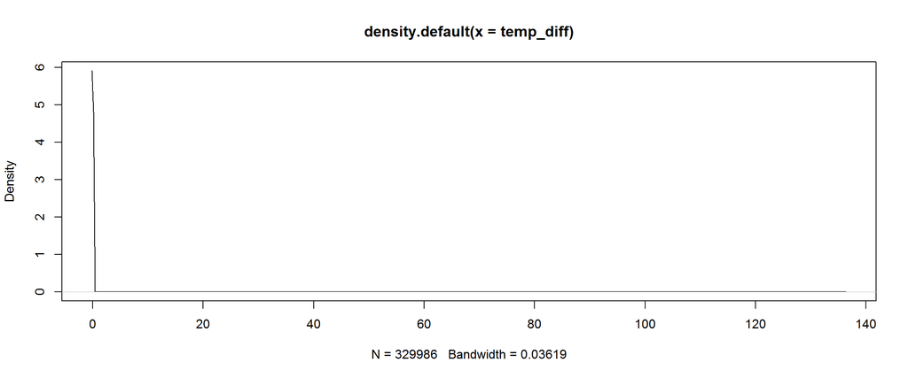

```r
temp_diff <- as.numeric(lc_loans$out_prncp) - as.numeric(lc_loans$out_prncp_inv)
plot(density(temp_diff))
```

Ok, it looks like they might be the same variables. One final check using cor

```r
cor(as.numeric(lc_loans$out_prncp), as.numeric(lc_loans$out_prncp_inv))
```

```
## [1] 0.9999993
```

We can confidently remove `out_prncp_inv` var since it is redundant.

```r
lc_loans <- lc_loans %>% select(-c(out_prncp_inv))
```

##### Combine the FICO score for high and low ranges into one var that is just the average of the two ranges.

```r
to_numeric <- c("fico_range_low", "fico_range_high")
lc_loans[to_numeric] <- sapply(lc_loans[to_numeric], as.numeric)


lc_loans$mean_fico <- (lc_loans$fico_range_low + lc_loans$fico_range_high)/2

# remove the features for fico range
lc_loans <- lc_loans %>% select(-c(fico_range_low, fico_range_high))
```

##### Extract numeric columns and look at their cor matrix

```r
# extract the numeric colums
num_vars <- sapply(lc_loans, is.numeric)
num_df <- lc_loans[, num_vars]


# look first at the number of na
na_count <- sapply(num_df, function(y) sum(length(which(is.na(y)))))
na_count <- data.frame(na_count)
na_count$name <- rownames(na_count)

# we have quite a bit of na's here. fortunately, for all of these variables
# we can replace NAs with 0. For instance, when num_tl_120dpd_2m (Number of
# accounts currently 120 days past due (updated in past 2 months)) is NA, we
# can assume that there are no delinquent accounts and have the cell
# replaced with 0.

num_df[is.na(num_df)] <- 0


print(findCorrelation(cor(num_df), cutoff = 0.9, names = TRUE))
```

```
## [1] "num_rev_accts"       "num_rev_tl_bal_gt_0" "tot_hi_cred_lim"
## [4] "funded_amnt_inv"     "funded_amnt"         "loan_amnt"
## [7] "total_rec_prncp"     "total_pymnt_inv"     "il_util"
```

There are no that many highly correlated variables, and the reason why they are correlated seems to be because most of them, in one way or another are related to the ammout borrowed.

I’m not going to remove these variables, despite their strong relationship to each other. The reason is because the sum differential between some of these variables is in the millions of dollars, and this is no chump change. Instead, I will simply replace the NAs for numerical values with 0.

```r
# find the index of numerical colums in lc_loans df
index <- which(names(lc_loans) %in% names(num_df))

# replace the numerical colums with na with 0
lc_loans[c(index)][is.na(lc_loans[c(index)])] <- 0
```

Create a a loan to income variable

```r
lc_loans$loan_to_inc <- ifelse(lc_loans$annual_inc == 0, 0, lc_loans$loan_amnt/lc_loans$annual_inc)
```

Fix the dti ratio; if income is 0, this number should be replaced with NA rather than 0.

```r
lc_loans$dti <- ifelse(lc_loans$annual_inc == 0, NA, lc_loans$dti)
```

Same issue goes for bc_util, il_util

```r
lc_loans$bc_util <- ifelse(lc_loans$bc_util == 0, NA, lc_loans$bc_util)
lc_loans$il_util <- ifelse(lc_loans$il_util == 0, NA, lc_loans$il_util)
```

#### `desc` provides a lot of interesting opportunities for NLP

```r
# examine a couple of entries
descriptions <- filter(lc_loans, !is.na(desc)) %>% select(desc)
descriptions[1:5, ]
```

```
## [1] I have problems with one of my loans what I have it is with household-beneficial finance bank it is for $15,250.00 and the interest rate is 25.8% and the payment is 323 monthly and I have 3 months pass due, I page all time in time but the situacion make loss that way cause the gas bill was ve…
## [2]   Borrower added on 12/22/11 > I need to upgrade my business technologies.<br>
## [3]   Borrower added on 12/22/11 > I plan to use this money to finance the motorcycle i am looking at. I plan to have it paid off as soon as possible/when i sell my old bike. I only need this money because the deal im looking at is to good to pass up.<br><br>  Borrower added on 12/22/11 > I plan …
## [4]   Borrower added on 12/21/11 > to pay for property tax (borrow from friend, need to pay back) & central A/C need to be replace. I'm very sorry to let my loan expired last time.<br>
## [5]   Borrower added on 12/18/11 > I am planning on using the funds to pay off two retail credit cards with 24.99% interest rates, as well as a major bank credit card with a 18.99% rate.  I pay all my bills on time, looking for a lower combined payment and lower monthly payment.<br>
## 100114 Levels: - Pay off Dell Financial: $ 1300.00 - Pay off IRS for 2005: $ 1400.00 - Pay off Mac Comp    : $ 1700.00 - Pay off Bill Me Later : $ 1000.00 - Pay off WAMU card  : $ 1000.00 - Pay off Becu Visa     : $ 1000.00 ...
```

I’ll create the following variables: -[DONE] variable that looks at whether a comment has been left -[DONE] number of comments the borrower has left; the number of comments can be counted based on the string “Borrower added on” -[DONE] Clean up -[DONE] Number of times $ sign appears -[DONE] the date when the first comment was left -[DONE] number of characters in description -[DONE] number of words in description -[DONE] sentiment analysis

```r
# Count number of comments
lc_loans$comment_n <- str_count(lc_loans$desc, "Borrower added on")

# Extract the date when the first comment was left
lc_loans$comment_date <- str_extract(lc_loans$desc, "\\d{2}/\\d{2}/\\d{2}")

# Comment exists (1=yes, 0=no)
lc_loans$comment_exists <- as.factor(ifelse(is.na(lc_loans$desc), 0, 1))

# Count the number of $ signs
lc_loans$dollar_signs <- str_count(lc_loans$desc, "\\$")

# create function for cleaning the text entries
clean_desc <- function(string) {
    # Lowercase
    temp <- tolower(string)
    # remove br tags
    temp <- str_replace_all(temp, "<br>", " ")
    # remove borrower added
    temp <- str_replace_all(temp, "borrower added on", " ")
    #' Remove everything that is not a letter
    temp <- str_replace_all(temp, "[^a-zA-Z\\s]", " ")
    # Shrink down to just one white space
    temp <- str_replace_all(temp, "[\\s]+", " ")
}

# lc_loans1<-lc_loans

lc_loans$desc <- clean_desc(as.character(lc_loans$desc))

# find the number of characters in description
lc_loans$nchar_desc <- nchar(lc_loans$desc)

# find the number of words; the easy solution is to use wc from qdap
lc_loans$words_n <- qdap::wc(lc_loans$desc)

# get sentiment
lc_loans$sentiment_syuzhet <- get_sentiment(lc_loans$desc, method = "syuzhet")

# get standford nlp sentiment tagger_path <-
# '/stanford-corenlp-full-2015-12-09'

# lc_loans$stanford_sentiment <- get_sentiment(lc_loans$desc,
# method='stanford', tagger_path)

# remove desc, since we're not using it anymore
lc_loans <- lc_loans %>% select(-c(desc))
rm(descriptions)
rm(num_df)
```

#### Create variables that measure pre-payment:

```
-[DONE] Create a variable that finds which loans were prepaid
-[DONE] Create a variable that for the duration of the loan
-[DONE] Create a variable that finds how much was lost in interest as a % of posible interest that could be gained if the loan was not prepaid.
```

Reading the variable description, it becomes clear that we are not given information about the duration of the loans. Instead, we have a variable that defines the month when the loan was issued and the month when the last payment on the loan was made. We can create a new variable that we’ll call duration, which will inlcude the number of months the loan was outstanding

```r
lc_loans$duration <- as.numeric(round((difftime(lc_loans$last_pymnt_d, lc_loans$issue_d,
    units = "day") * 12)/365.25, 1))
```

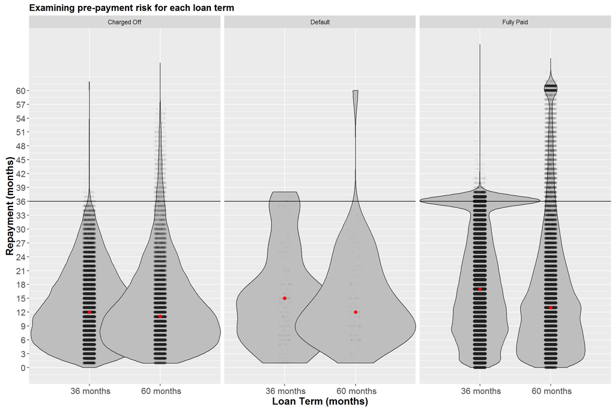

```r
ggplot(data = lc_loans, aes(x = term, y = duration)) + geom_violin(fill = "grey",
    width = 1.7) + geom_jitter(shape = 16, position = position_jitter(0.2),
    alpha = 1/60) + scale_y_continuous(breaks = seq(0, 60, 3)) + stat_summary(fun.y = median,
    geom = "point", size = 2, color = "red") + ggtitle("Examining pre-payment risk for each loan term") +
    labs(x = "Loan Term (months)", y = "Repayment (months)") + theme(axis.title.x = element_text(face = "bold",
    colour = "black", size = 14), axis.title.y = element_text(face = "bold",
    colour = "black", size = 14), axis.text.x = element_text(size = 12), axis.text.y = element_text(size = 12),
    plot.title = element_text(lineheight = 0.8, face = "bold", colour = "black")) +
    facet_wrap(~loan_status) + geom_hline(yintercept = 36)
```

# let’s check that the medians for each group

```r
lc_loans %>% filter(!is.na(duration)) %>% group_by(loan_status, term) %>% summarise(n = n(),
    duration_median = median(duration))
```

```
## Source: local data frame [6 x 4]
## Groups: loan_status [?]
##
##   loan_status       term      n duration_median
##        (fctr)     (fctr)  (int)           (dbl)
## 1 Charged Off  36 months  38077            12.0
## 2 Charged Off  60 months  22177            11.1
## 3     Default  36 months    189            15.0
## 4     Default  60 months    112            12.0
## 5  Fully Paid  36 months 216311            17.0
## 6  Fully Paid  60 months  52440            13.0
```

These numbers looks very suspicious. There is no way the pre-payment rates are that high.

Because we don’t have direct measure of loan duration, I’ll try to derive a second measure of duration based on total_payments and installment variables. I hope to get the same results as above.

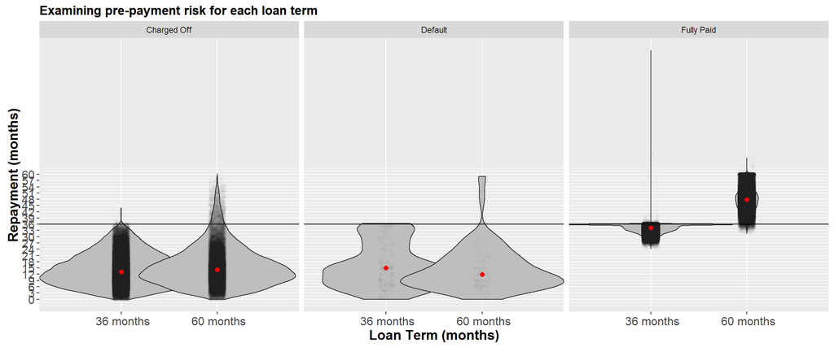

```r
lc_loans <- mutate(lc_loans, duration2 = round(total_pymnt/installment, 1))
ggplot(data = lc_loans, aes(x = term, y = duration2)) + geom_violin(fill = "grey",
    width = 1.7) + geom_jitter(shape = 16, position = position_jitter(0.2),
    alpha = 1/60) + scale_y_continuous(breaks = seq(0, 60, 3)) + stat_summary(fun.y = median,
    geom = "point", size = 2, color = "red") + ggtitle("Examining pre-payment risk for each loan term") +
    labs(x = "Loan Term (months)", y = "Repayment (months)") + theme(axis.title.x = element_text(face = "bold",
    colour = "black", size = 14), axis.title.y = element_text(face = "bold",
    colour = "black", size = 14), axis.text.x = element_text(size = 12), axis.text.y = element_text(size = 12),
    plot.title = element_text(lineheight = 0.8, face = "bold", colour = "black")) +
    facet_wrap(~loan_status) + geom_hline(yintercept = 36)
```

```r
lc_loans %>% filter(!is.na(duration2)) %>% group_by(loan_status, term) %>% summarise(n = n(),
    duration_median = median(duration2))
```

```
## Source: local data frame [6 x 4]
## Groups: loan_status [?]
##
##   loan_status       term      n duration_median
##        (fctr)     (fctr)  (int)           (dbl)
## 1 Charged Off  36 months  38570            13.1
## 2 Charged Off  60 months  22359            14.1
## 3     Default  36 months    193            15.0
## 4     Default  60 months    113            11.9
## 5  Fully Paid  36 months 216311            34.3
## 6  Fully Paid  60 months  52440            47.9
```

Ok, so we got different numbers. Which one is the correct one? My instinct tells me that the second measure is right. I still have the option of calculating duration based on the ammout of interest that got paid.

```r
lc_loans %>% select(funded_amnt, term, int_rate, installment, total_rec_int,
    duration, duration2, loan_status, collection_recovery_fee, total_pymnt,
    total_rec_prncp, total_rec_late_fee) %>% head(2)
```

```
##   funded_amnt       term int_rate installment total_rec_int duration
## 1        7200  36 months   0.0532      216.83         23.41        1
## 2       30000  60 months   0.1825      765.89        560.99        2
##   duration2 loan_status collection_recovery_fee total_pymnt
## 1      33.3  Fully Paid                       0     7223.41
## 2      39.9  Fully Paid                       0    30560.99
##   total_rec_prncp total_rec_late_fee
## 1            7200                  0
## 2           30000                  0
```

Ok, the second measure is wrong; we are keeping duration 1 as the correct measure. Nontheless, we have another issue. - For a $7200 loan for a term of 36months, funded at a rate of 5.32%, the installment comes to 216.83, just like in the example above. Nontheless, the interest rate comes to about **$32** not **23.41**. This means that they might be amortizing at a daily rather than monthly schedule, even though I can’t find any info on the website about this. IN other words, they charge interest on monthly installments, but if you pay at the middle of the month, the interest portion of the loan is smaller. To get more accurate measures of duration, it would be useful to reverse engineer durations based on the interest rate paid on a daily amortizing schedule.

I’ll do a quick check, just to see if they use monthly ammortizing when the loans are matured.

```r
lc_loans %>% select(funded_amnt, term, int_rate, installment, total_rec_int,
    duration, duration2, loan_status, collection_recovery_fee, total_pymnt,
    total_rec_prncp, total_rec_late_fee) %>% filter(duration == 36) %>% head(2)
```

```
##   funded_amnt       term int_rate installment total_rec_int duration
## 1        8500  36 months   0.1171      281.15       1626.09       36
## 2        8000  36 months   0.1677      284.31       2258.24       36
##   duration2 loan_status collection_recovery_fee total_pymnt
## 1      36.0  Fully Paid                       0    10126.09
## 2      36.1  Fully Paid                       0    10273.24
##   total_rec_prncp total_rec_late_fee
## 1            8500                  0
## 2            8000                 15
```

Ok, things look fine in this aspect.

Remove duration2, since it is not useful

```r
lc_loans <- lc_loans %>% select(-c(duration2))
```

Now, I will create a variable that classifies a loan as prepaid or matured.

```r
# the term variable needs to be changed to numeric
lc_loans$term2 <- gsub("['months'|[:blank:]]", "", lc_loans$term)
lc_loans$term2 <- as.numeric(lc_loans$term2)

# create prepaid variable 1=yes, 0=no); Add one month, just to take into
# account some end of date bulk pre-payments.
lc_loans$prepaid <- ifelse((lc_loans$duration + 1) < lc_loans$term2, 1, 0)
```

Next, I will create a variable that finds the cumulative interest that could be gained if the loan reached maturity. This will allow me later to find how much was lost in interest. This is the formula for cumulative interest:
$$I_c==(((p-m*q/i)*(1+(i/q))^{b-1}+m*q/i)-((p-m*q/i)*(1+(i/q))^e+m*q/i))-m*(e-b+1)$$

Where: - $I_c$ - cumulative interest - $p$ - principal - $i$ - annual interest rate - $n$ - number of payments (months) - $b$ - payment start - $e$ - payments per year - $m$ - installment - $q$ - payments per year

```r
prepayment_calc <- function(p, i, n, b, e, m, q) {
    cumI = (((p - m * q/i) * (1 + (i/q))^(b - 1) + m * q/i) - ((p - m * q/i) *
        (1 + (i/q))^e + m * q/i)) - m * (e - b + 1)
    -cumI
}
```

Create variable for possible interest and for proportion of interest lost

```r
lc_loans <- lc_loans %>% mutate(possible_interest = prepayment_calc(loan_amnt,
    int_rate, term2, 1, term2, installment, 12), int_p_lost = 1 - total_rec_int/possible_interest)
```

Let me just check something really quick to see how the total_pymnt column was calculated

```r
lc_loans %>% # select(loan_amnt,funded_amnt,term,int_rate,installment, total_rec_int,
# duration,loan_status,collection_recovery_fee,
# total_pymnt,total_rec_prncp,total_rec_late_fee, loan_status,out_prncp,
# recoveries,collection_recovery_fee) %>%
filter(loan_status == "Default") %>% head(1)
```

```
##       id loan_amnt funded_amnt funded_amnt_inv       term int_rate
## 1 635663     12000       12000        11793.18  60 months   0.0962
##   installment grade sub_grade emp_title emp_length home_ownership
## 1      252.73     B        B3      <NA>          0            OWN
##   annual_inc verification_status    issue_d loan_status            purpose
## 1      42000        Not Verified 2010-12-01     Default debt_consolidation
##                title addr_state   dti delinq_2yrs earliest_cr_line
## 1 Loan Consolidation         AR 17.97           0       1994-12-01
##   inq_last_6mths mths_since_last_delinq mths_since_last_record open_acc
## 1              3                      0                      0        6
##   pub_rec revol_bal revol_util total_acc initial_list_status out_prncp
## 1       0      4462      0.525        15                   f    269.31
##   total_pymnt total_pymnt_inv total_rec_prncp total_rec_int
## 1     14884.8        14579.94        11730.68       3154.12
##   total_rec_late_fee recoveries collection_recovery_fee last_pymnt_d
## 1                  0          0                       0   2015-12-01
##   last_pymnt_amnt next_pymnt_d last_credit_pull_d
## 1          252.73     Jun-2016         2015-11-01
##   collections_12_mths_ex_med mths_since_last_major_derog acc_now_delinq
## 1                          0                           0              0
##   tot_coll_amt tot_cur_bal open_acc_6m open_il_6m open_il_12m open_il_24m
## 1            0           0           0          0           0           0
##   mths_since_rcnt_il total_bal_il il_util open_rv_12m open_rv_24m
## 1                  0            0      NA           0           0
##   max_bal_bc all_util total_rev_hi_lim inq_fi total_cu_tl inq_last_12m
## 1          0        0                0      0           0            0
##   acc_open_past_24mths avg_cur_bal bc_open_to_buy bc_util
## 1                    0           0              0      NA
##   chargeoff_within_12_mths delinq_amnt mo_sin_old_il_acct
## 1                        0           0                  0
##   mo_sin_old_rev_tl_op mo_sin_rcnt_rev_tl_op mo_sin_rcnt_tl mort_acc
## 1                    0                     0              0        0
##   mths_since_recent_bc mths_since_recent_bc_dlq mths_since_recent_inq
## 1                    0                        0                     0
##   mths_since_recent_revol_delinq num_accts_ever_120_pd num_actv_bc_tl
## 1                              0                     0              0
##   num_actv_rev_tl num_bc_sats num_bc_tl num_il_tl num_op_rev_tl
## 1               0           0         0         0             0
##   num_rev_accts num_rev_tl_bal_gt_0 num_sats num_tl_120dpd_2m num_tl_30dpd
## 1             0                   0        0                0            0
##   num_tl_90g_dpd_24m num_tl_op_past_12m pct_tl_nvr_dlq percent_bc_gt_75
## 1                  0                  0              0                0
##   pub_rec_bankruptcies tax_liens tot_hi_cred_lim total_bal_ex_mort
## 1                    0         0               0                 0
##   total_bc_limit total_il_high_credit_limit issue_year issue_month
## 1              0                          0       2010         Dec
##   credit_years mean_fico loan_to_inc comment_n comment_date comment_exists
## 1           16       742   0.2857143         1     12/23/10              1
##   dollar_signs nchar_desc words_n sentiment_syuzhet duration term2 prepaid
## 1            0        195      42              0.25       60    60       0
##   possible_interest  int_p_lost
## 1          3163.542 0.002978206
```

This makes no sense, which worries me that the loan status description might be incorrect in some places. The person above paid 14884.8 on their 12k loan. They basically made every payment without any late payments and then didn’t pay the last installment. Also, the total_payment column is off by a couple hundred dollars. Let me check if this is the case for other loans.

```r
p_off <- lc_loans %>% mutate(paid = total_pymnt - total_rec_prncp - total_rec_int -
    total_rec_late_fee - recoveries)
# note that i;m not including the collection_recovery_fee, since that one is
# already included in recoveries var.

describe(p_off$paid)
```

```
## p_off$paid
##          n    missing     unique       Info       Mean        .05
##     329986          0     150045          1 -7.418e-06 -3.444e-03
##        .10        .25        .50        .75        .90        .95
## -1.834e-03 -1.364e-12  0.000e+00  2.900e-09  1.810e-03  3.370e-03
##
## lowest : -0.01 -0.01 -0.01 -0.01 -0.01
## highest:  0.01  0.01  0.01  0.01  0.01
```

```r
rm(p_off)
```

For most of the loans the pay differential is small. It seems like we’ll have no issues using the total_pymnt, funded_amnt, and duration to calculate out return metrics.

# Create some new return measures

[output not shown]

```r
lc_loans <- lc_loans %>% mutate(cum_r = (total_pymnt - funded_amnt)/funded_amnt,
    ann_r = ((1 + cum_r)^(12/duration)) - 1) %>% filter(!is.na(ann_r))
```

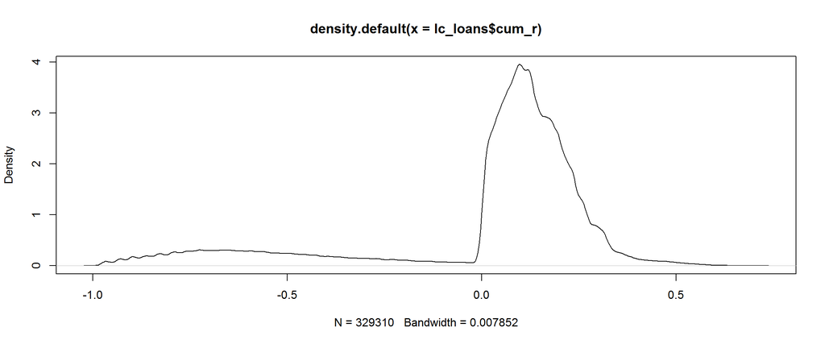

```r
# the cummullative return distribution
plot(density(lc_loans$cum_r))
```

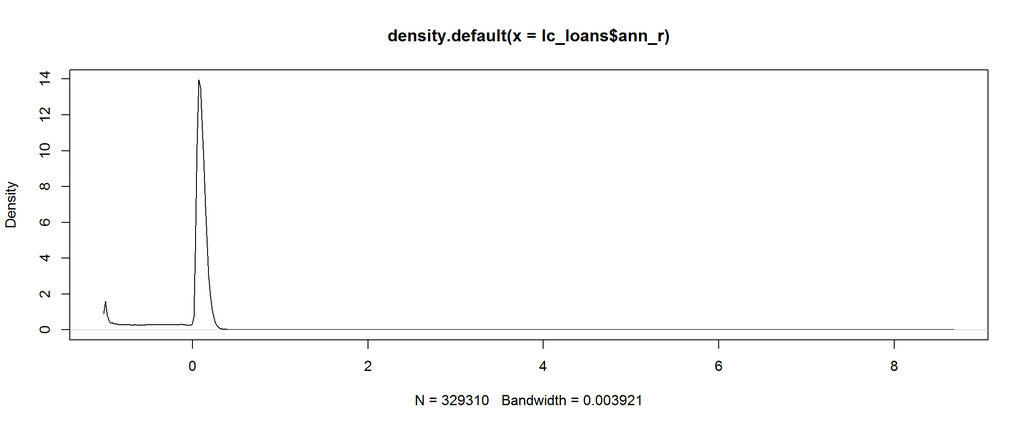

```r
# the annual return distribution
plot(density(lc_loans$ann_r))
```

```r
describe(lc_loans$ann_r)
```

```
## lc_loans$ann_r
##       n missing  unique    Info    Mean     .05     .10     .25     .50
##  329310       0  320190       1     Inf -0.8780 -0.5323  0.0492  0.0833
##     .75     .90     .95
##  0.1236  0.1643  0.1934
##
## lowest : -1.000 -1.000 -1.000 -1.000 -1.000
## highest:  1.624  3.158  3.800  8.671    Inf
```

Explanation for INF and for why ann_r is sometimes larger than the interest_rate: - The only explanation for why there is an INF value is because there is a loan that has a duration of 0, leading to division by 0. - The ann_r is sometimes larger because the duration var is not an exact measure of loan duration. For instance,

```r
# cumulative interest paid if duration is 1 for the first loan above
a <- prepayment_calc(25500, 0.1999, 36, 1, 1, 947.55, 12)

# $424.7875

# cumulative interest paid if duration is 2 for the first loan above
b <- prepayment_calc(25500, 0.1999, 36, 1, 2, 947.55, 12)

c(a, b)
```

```
## [1] 424.7875 840.8666
```

```r
lc_loans <- lc_loans %>% mutate(ann_r = ifelse(ann_r > int_rate, int_rate, ann_r))
```

Done Cleaning

Write the lc_loans file to disk

```r
# write.csv(lc_loans, 'lc_loans.csv')
```